# Weather-Related Damages to Life and Property in the United States: a Retrospective Analysis from National Weather Service Data Between 1950 and 2011

Marco Baciarello

3/28/2021

## Synopsis

In this data analysis we studied data from the National Weather Service, detailing weather events and the damages they caused between 1950 and 2011. Most data entry was poorly regulated, especially during the database’s early years, so text mining was required in order to classify weather events in more generalizable categories. From this database, it appears that floods were by far the main cause of monetary losses in the studied period; it is likely that Hurricane Katrina and, to a lesser extent, Sandy were the main drivers of this result. Injuries and loss of life occurred significantly more often as consequences of tornadoes. Other wind events, extreme temperatures and floods were also associated with significant loss of life.

## Data Processing

First, we download the data file and load it into an R object. We’re using a `tidyr`-centric approach, leveraging on the full suite of library found in package `tidyverse`.

```r
# Check if data dir exists -> create one
if (!file.exists("data")) {
    dir.create("./data")
}

# Get the data
if (!file.exists("data/stormdata.csv.bz2")) {
    download.file("https://d396qusza40orc.cloudfront.net/repdata%2Fdata%2FStormData.csv.bz2", "data/stormdata.csv.bz2")
}

# Read data in. fread seems way faster than other solutions.
rdata <- fread("data/stormdata.csv.bz2", data.table = FALSE)
# Convert to "lazy data.table" which will accept dplyr functions
data <- lazy_dt(rdata)
```

### Time formatting

We create 2 new table columns; one is a properly-formatted `POSIXct` column including date and time information from columns `BGN_DATE` and `BGN_TIME`. We will ignore end times of phenomena for now.

```r
# TECH NOTE: We're using the `dtplyr` interface to use `tidyverse` grammar but
# run data.table code, for increased performance on large tables.

# Format data
fdata <- data %>%
    mutate(
        # Paste date and time For some reason, data includes a fixed time 00:00
        # which we don't need, so we split and get the first fragment
        temp_datetime = paste(strsplit(BGN_DATE, " ")[[1]][1], BGN_TIME),
        # Convert to datetime;
        utc_datetime = as.POSIXct(
            temp_datetime,
            format = "%m/%d/%Y %H%M"),
        # correct timezones (there are older/unsupported abbreviations)
        c_timezone = recode(TIME_ZONE,
                            CDT = "US/Central",
                            CST = "US/Central",
                            UNK = "UTC",
                            MDT = "US/Mountain",
                            AST = "US/Eastern",
                            ADT = "US/Eastern",
                            CSt = "US/Central",
                            CSC = "UTC",
                            SCT = "US/Central",
                            ESY = "US/Eastern",
                            SST = "US/Samoa",
                            AKS = "US/Alaska",
                            GST = "US/Central"
                            ),
        # # Convert each time to its own time zone
        datetime = lubridate::force_tzs(utc_datetime, tzones = c_timezone),
        # Force POSIXct format, otherwise data won't be usable in data.table
        # package functions
        begin_time = as.POSIXct(datetime),
        # Finally, change EVTYPE into a factor ordered by frequency (may be
        # CPU-intensive)
        event = fct_infreq(as.factor(str_to_lower(EVTYPE)))
    ) %>%
    # Need to drop non-POSIXlt columns for data.table compatibility
    select(-contains("datetime")) %>%
    # End dtplyr "session," translate into data.table code and run
    as_tibble()
```

### Property and agricultural damages

A second column will be created in order to reconstruct information on property damage: columns `PROPDMGEXP` specifies an “exponent” for `PROPDMG`, in the form of a mathematical suffix: K for thousands, M for millions, and so on… Values can also be integers, in which case they seem to indicate that the reported damage value is to be multiplied by 10 (see full legend here. We will compute a column containing the actual amount as an integer or double. Same operation will be performed for `CROPDMG` and `CROPDMGEXP`.

```r
unique(fdata$PROPDMGEXP)
```

```
##  [1] "K" "M" ""  "B" "m" "+" "0" "5" "6" "?" "4" "2" "3" "h" "7" "H" "-" "1" "8"
```

```r
unique(fdata$CROPDMGEXP)
```

```
## [1] ""  "M" "K" "m" "B" "?" "0" "k" "2"
```

```r
# Cannot use dtplyr here because of error: Can't rename variables in this context.

temp_data <- fdata %>%
    mutate(
        year = as.integer(lubridate::year(begin_time)),
        prop_mult = case_when(
            PROPDMGEXP %in% c(0, 1, 2, 3, 4, 5, 6, 7, 8) ~ 10,
            PROPDMGEXP %in% c('m', 'M') ~ 1000000,
            PROPDMGEXP %in% c('k', 'K') ~ 1000,
            PROPDMGEXP %in% c('b', 'B') ~ 1000000000,
            PROPDMGEXP %in% c('h', 'H') ~ 100,
            PROPDMGEXP == '+' ~ 1,
            # Vector must be double because of limitations in `case_when`, so we
            # can't set a value to NA; use dummy code and convert later.
            TRUE ~ -999999
        ),
        crop_mult = case_when(
            PROPDMGEXP %in% c(0, 1, 2, 3, 4, 5, 6, 7, 8) ~ 10,
            CROPDMGEXP %in% c('m', 'M') ~ 1000000,
            CROPDMGEXP %in% c('k', 'K') ~ 1000,
            CROPDMGEXP %in% c('b', 'B') ~ 1000000000,
            CROPDMGEXP %in% c('h', 'H') ~ 100,
            CROPDMGEXP == '+' ~ 1,
            # Vector must be double because of limitations in `case_when`, so we
            # can't set a value to NA; use dummy code and convert later.
            TRUE ~ -999999
        ),
        # Change dummy value into NA
        across(ends_with("_mult"), ~na_if(., -999999)),
        crop_dmg = CROPDMG * crop_mult,
        prop_dmg = PROPDMG * prop_mult,
        tot_dmg = prop_dmg + crop_dmg
    )

# Switch back to dtplyr syntax and clean up
temp_data <- lazy_dt(temp_data)

# Filter out events which did not cause any injuries, fatalities or monetary
# damages
mdata <- temp_data %>% filter(
  (INJURIES > 0) |
    (FATALITIES > 0) |
    (tot_dmg > 0)
) %>%
  # Apply data.table code
  as_tibble()
```

### Injuries and fatalities

These data do not seem to be needing any significant adjustments:

```r
skimr::skim(mdata$INJURIES)
```

Data summary

| Name | mdata$INJURIES |
| --- | --- |
| Number of rows | 115397 |
| Number of columns | 1 |
| _______________________ |  |
| Column type frequency: |  |
| numeric | 1 |
| ________________________ |  |
| Group variables | None |

**Variable type: numeric**

| skim_variable | n_missing | complete_rate | mean | sd | p0 | p25 | p50 | p75 | p100 | hist |
| --- | --- | --- | --- | --- | --- | --- | --- | --- | --- | --- |
| data | 0 | 1 | 1.22 | 15.15 | 0 | 0 | 0 | 0 | 1700 | ▇▁▁▁▁ |

```r
skimr::skim(mdata$FATALITIES)
```

Data summary

| Name | mdata$FATALITIES |
| --- | --- |
| Number of rows | 115397 |
| Number of columns | 1 |
| _______________________ |  |
| Column type frequency: |  |
| numeric | 1 |
| ________________________ |  |
| Group variables | None |

**Variable type: numeric**

| skim_variable | n_missing | complete_rate | mean | sd | p0 | p25 | p50 | p75 | p100 | hist |
| --- | --- | --- | --- | --- | --- | --- | --- | --- | --- | --- |
| data | 0 | 1 | 0.13 | 2.14 | 0 | 0 | 0 | 0 | 583 | ▇▁▁▁▁ |

### Selection of variables of interest

According to the requirements for this report, we will be describing associations between weather events and human and economical damages. After preparatory operations performed above, we will now drop variables which are not of interest to these analyses, in order to make data more easily readable and reduce resource requirements.

```r
# Select useful columns
lean_data <- mdata %>%
    select(REFNUM, event, year, c_timezone,
           FATALITIES, INJURIES, tot_dmg)
```

### Selection of events

The vast majority of events have caused no damage to people or property. More than 90% of event *types* are not associated with damage, and many of them have occurred just once since 1950. This is mostly due to numerous, uncorrected mistakes made in data entry over the first ⅔ of the database’s life.

```r
# Make a copy of data and cast as DT
sel_data <- as.data.table(lean_data)
# Apply final transformations to DT
sel_data2 <- sel_data[, .(
    counter = .N, # Count elements in group
    # Total monetary damages per group
    total_dmg = sum(tot_dmg, na.rm = TRUE),
    # Total fatalities
    fatalities = sum(FATALITIES, na.rm = TRUE),
    # Injuries
    injuries = sum(INJURIES, na.rm = TRUE)
  ),
  # Grouping by event type
  by = .(event)][
    ,
    # Compute a "percent rank": rank events by number of
    # occurrences (desc), then assign a percentile by
    # dividing rank by denominator (i.e. nrows)
    # Note double dot syntax to access calling scope
    `:=`(perc_rank = frankv(counter)/.N,
         # Same for monetary damage
         dmg_rank = frankv(total_dmg)/.N,
         # And life damage
         inj_rank = frankv(injuries)/.N,
         fat_rank = frankv(fatalities)/.N
    )
  ][
    # Filter for frequency rank >=95th
    perc_rank >= 0.80
  ][
    order(-counter)
  ]
```

```r
gdata <- as.data.table(temp_data)
# With DT syntax, group and compute relevant sums
totals <- gdata[,.(sum_inj = sum(INJURIES, na.rm = T),
               sum_fat = sum(FATALITIES, na.rm = T),
               sum_dmg = sum(tot_dmg, na.rm = T))]

selected <- sel_data2[,.(sum_inj = sum(injuries, na.rm = T),
               sum_fat = sum(fatalities, na.rm = T),
               sum_dmg = sum(total_dmg, na.rm = T))]

# Proportion of damages in selected events as opposed to total
round((selected/totals), digits = 2)
```

```
##    sum_inj sum_fat sum_dmg
## 1:    0.98    0.95    0.94
```

Events below the 80<sup>th</sup> percentile of frequency are mostly irrelevant to the analysis. To confirm this, we calculated total damages, injuries and fatalities from the global data and from the selected data. The ratios of the selected data to the global data is near 1 (see above), despite the selected data table having only a fraction of the event types (898 *vs.* 49).

### Aggregation of events by type

We then aggregate event types into arbitrary categories, both for clarity and because there is artificial variability in the form of spelling errors and variations (*e.g.*: `hail`, `marine hail`, `hail/wind`, `small hail` and so forth…)

Nested loops is our way of going through a factor variable and associating each value to a value in a new factor variable (many-to-one relationship.). The need for loops seems to be related to the fact that these vars are stored as factors, and the lack of a specific function in the forcats package; fct_collapse() might have been one solution, but it takes the exact factor level names—since there were almost 1000 different possible levels, it would have been impractical to call this function.

```r
# Functions to aggregate (collapse) factor levels require specific values, specified in a named vector. Here, we use "data mining" to generate such vector.

# Create regexp patterns to match to. The following is also the priority order
# with which events will be assigned to a category.
new_fcts <- list(
  hail = c("hail"),
  tornado = c("torn", "nado"),
  tsunami = c("tsun"),
  stormy = c("storm*", "thunder*", "tstm", "rain", "precip", "hurric", "spout"),
  lightning = c("lightn"),
  flood = c("flood", "seiche", "fld"),
  cold = c("snow", "cold", "ice", "sleet", "^*inter", "blizz", "avalan"),
  heat = c("heat", "hot", "summ", "warm"),
  windy = c("wind", "devil", "b*rst"),
  fog = c("fog"),
  maritime = c("sea*", "ocean*", "mari[nt]*",
               "curr*", "tid*", "surf*", "wav", "swell"),
  drought = c("drought"),
  fire = c("fire", "blaze", "smok"),
  landslide = c("slide")
)

# Initialize list, vector and counter for the loop
old_events <- vector("list", 14)
new_events <- c()
i <- 1
```

We create a list of possible synonims for weather events. In the inner loop, the factor variable is run (using `stringr::subset()` sequentially against each list element and its children. Where there’s a match, the function returns the full value of the variable. We aggregate these values in a vector. In the outer loop, the unique values (i.e., factor levels) are appended to a second list. The second list has a list-element for each of the new factor levels; the old factor levels are thus stored as children of the new ones, based on matching with our criteria.

Once complete, the list *could* be used as a named vector. However, for some reason we had to insert each element manually using list$element syntax.

```r
suppressWarnings(
    # For every new event category
    for (i in seq(1:length(new_fcts))) {
        # Prepare storage array
        old_instances <- c()
        k <- 1
        # Loop over elements in list element
        for (k in seq(1:length(new_fcts[[i]]))) {
            # Match old event instances
            old_instances <- c(old_instances,
                               str_subset(sel_data2$event, new_fcts[[i]][k])
                                )
            k <- k + 1
        }
        # Add to list
        old_events[[i]] <- unique(old_instances)
        i <- i + 1
    }
)
# Name (tag) list elements
names(old_events) <- names(new_fcts)

# TODO: switch to using list names instead of manual entry of new factor levels
sel_data2$event2 <- fct_collapse(
  sel_data2$event,
  hail = old_events$hail,
  tornado = old_events$tornado,
  tsunami = old_events$tsunami,
  stormy = old_events$stormy,
  lightning = old_events$lightning,
  flood = old_events$flood,
  cold = old_events$cold,
  heat = old_events$heat,
  windy = old_events$windy,
  maritime = old_events$maritime,
  fog = old_events$fog,
  drought = old_events$drought,
  fire = old_events$fire,
  landslide = old_events$landslide,
  other_level = "Other events"
) %>%
  # Adjust spelling/capitalization of factor levels
  fct_recode(
    "Hail" = "hail",
    "Winds" = "windy",
    "Tornadoes" = "tornado",
    "Floods" = "flood",
    "Lightnings" = "lightning",
    "Cold weather" = "cold",
    "Storms/Rains" = "stormy",
    "Oceanic events" = "maritime",
    "Fires" = "fire",
    "Droughts" = "drought",
    "Hot weather" = "heat",
    "Fog" = "fog",
    "Landslides" = "landslide",
    "Tsunamis" = "tsunami"
  ) %>%
  # Reorder according to frequency, desc
  fct_infreq()
```

The choice of the fourteen categories was arbitrary, based on observation of event types appearing in the selected data. There are limitations to this approach, namely: events belonging to more than one category; and possible oversight of extremely rare events.

```r
# Make a copy of data to be sorted by damage total, descending, for use in
# damage-related plots.
dmgdata <- sel_data2 %>%
    group_by(event2) %>%
    summarise(total_dmg = sum(total_dmg),
              total_inj = sum(injuries),
              total_fat = sum(fatalities)
              ) %>%
    mutate(event2 = as.character(event2)) %>%
    arrange(desc(total_dmg)) %>%
    as_tibble()
```

## Results

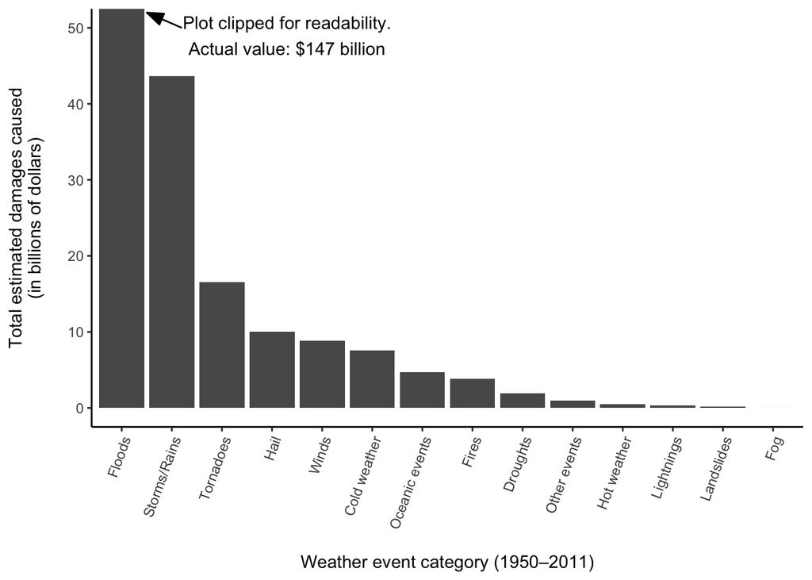

**Fig. 1:** Total damages (from lost crops and property) by weather event category. For readability, the first column has been clipped instead of being changed to a logarithmic scale.

```r
### Damage plot

dmgdata %>%
  ggplot(aes(
    x = reorder(event2, -total_dmg),
    y = total_dmg)) +
  geom_col() +
  scale_y_continuous(
    labels = scales::label_dollar(prefix = NULL,
                                  scale = 1e-9,
                                  largest_with_cents = 1),
    name = "Total estimated damages caused\n(in billions of dollars)\n"
  ) +
  scale_x_discrete("\nWeather event category (1950–2011)") +
  coord_cartesian(ylim = c(0, 5e10)) +
  annotate("segment", x= 2.2, xend = 1.5, y = 50e9, yend = 52e9,
           arrow = arrow(angle = 20,
                         length = unit(0.15, "inches"),
                         type = "closed")
  ) +
  annotate("text",
           x = 4.3, y = 49e9,
           label = "Plot clipped for readability.\nActual value: $147 billion") +
  theme_classic() +
  theme(axis.text.x = element_text(angle = 70, hjust = 1))
```

Data about injuries and fatalities is significantly different. The main culprits here seem to be tornadoes, which are presumably associated with danger from flying object. Other types of wind events are between 2<sup>nd</sup> and 4<sup>th</sup> ranks. Extremely hot weather seems to have been an important cause of death (2<sup>nd</sup> rank, with 50% as many victims as tornadoes).

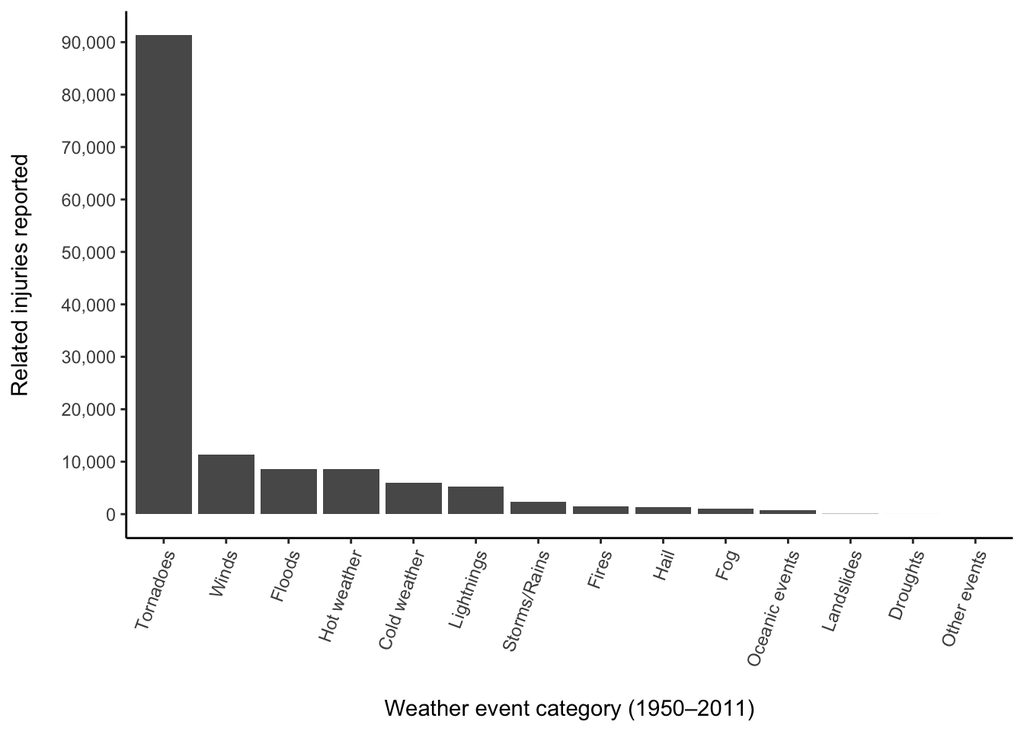

**Fig. 2:** Total injuries by weather event category.

```r
### Injuries plot

dmgdata %>%
    ggplot(aes(
        x = reorder(event2, -total_inj),
        y = total_inj)) +
    geom_col() +
    scale_x_discrete("\nWeather event category (1950–2011)") +
    scale_y_continuous(name = "Related injuries reported\n",
                       breaks = seq(0, 1e5, 1e4),
                       labels = scales::label_comma()) +
    theme_classic() +
    theme(axis.text.x = element_text(angle = 70, hjust = 1))
```

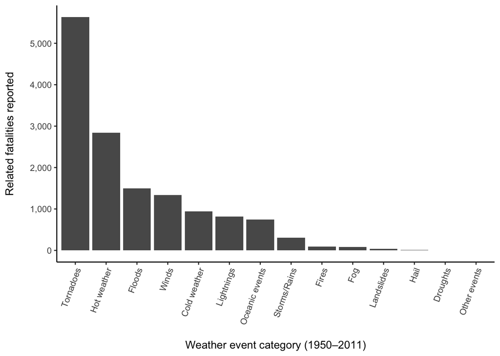

**Fig. 3:** Total fatalities by weather event category.

```r
### Fatalities plot

dmgdata %>%
    ggplot(aes(
        x = reorder(event2, -total_fat),
        y = total_fat)) +
    geom_col() +
    scale_x_discrete("\nWeather event category (1950–2011)") +
    scale_y_continuous(name = "Related fatalities reported\n",
                       #breaks = scales::extended_breaks(),
                       breaks = seq(0, 5e3, 1e3),
                       labels = scales::label_comma()) +
    theme_classic() +
    theme(axis.text.x = element_text(angle = 70, hjust = 1))
```

## Conclusions

Massive flooding has historically been associated with the greatest crop and property damages, with rain/storms a very distant second. Tornadoes are the most dangerous type of events in terms of human life.